# Validate candidates and filter motifs

Amin Bazaz, Heraldo Borges, Eduardo Ogasawara

2018-08-23

In this step, we have our candidates generated from the original dataset.

## Check the occurrences

We must now validate these candidates. To do this, we will use as a restriction the occurrences. There are two types of occurrences in our approach : - `Global occurrences (GO)`: the number of occurrences in the entire dataset - `Spatial occurrences (SO)`: the number of spatial-series containing the candidate

The thresholds are used to select from the list of candidates the real motifs

- `Sigma`: threshold to check the minimal number of **global** occurrences of each motif.
- `Kappa`: threshold to check the minimal number of **spatial** occurrences of each motif.

Here an example with three scenarios:

- Scenario 1: kappa = sigma = **4**
- Scenario 2: kappa = sigma = **8**
- Scenario 3: kappa = sigma = **12**

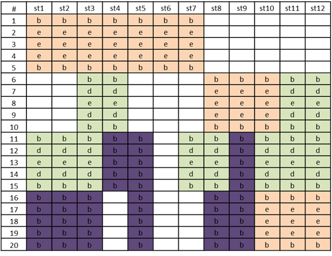

Example of encoded spatial-time series

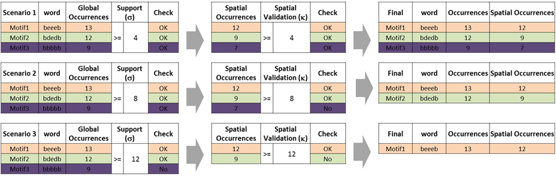

Result of the three scenarios

## Filter motifs

Filter motifs by removing isolated motifs and rechecking occurrences.

To find these isolated motifs we use the cluster method.

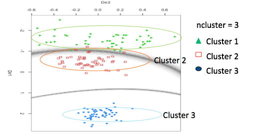

Cluster method

If the motif does not have a neighbor then it is deleted. After that when all isolated motifs are deleted, we recheck like the previous step the occurrences.